# lab4_clustering

**Практическое задание №4 по курсу "Методы и технологии машинного обучения"**

*Арешин Станислав Олегович М8О-111М-21*

**Задание**

- Для произвольного набора данных с известными классами найти лучший алгоритм кластеризации, согласующийся с ground truth (максимизировать supervised метрики путем выбора алгоритма и его гиперпараметров).
- Построить 2D и 3D визуализации с помощью TSNE.

```python
import numpy as np
import pandas as pd
import matplotlib.pyplot as plt
import seaborn as sns
import plotly.graph_objects as go

sns.set_style("darkgrid", {"grid.color": ".6", "grid.linestyle": ":"})

%matplotlib inline
```

# Предобработка

## Загрузка данных

Датасет: https://www.kaggle.com/abisheksudarshan/customer-segmentation

Решение задачи сегментации потребителей. Сегментация потребителей - это практика разделения клиентской базы на группы людей, схожих по определенным признакам, имеющим отношение к маркетингу, таким как возраст, пол, интересы и покупательские привычки.

В данной задаче клиенты разделены на 4 сегмента (A, B, C, D).

```python
df = pd.read_csv('train.csv').drop(['ID'], axis = 1)
df.head()
```

|  | Gender | Ever_Married | Age | Graduated | Profession | Work_Experience | Spending_Score | Family_Size | Var_1 | Segmentation |
| --- | --- | --- | --- | --- | --- | --- | --- | --- | --- | --- |
| 0 | Male | No | 22 | No | Healthcare | 1.0 | Low | 4.0 | Cat_4 | D |
| 1 | Female | Yes | 38 | Yes | Engineer | NaN | Average | 3.0 | Cat_4 | A |
| 2 | Female | Yes | 67 | Yes | Engineer | 1.0 | Low | 1.0 | Cat_6 | B |
| 3 | Male | Yes | 67 | Yes | Lawyer | 0.0 | High | 2.0 | Cat_6 | B |
| 4 | Female | Yes | 40 | Yes | Entertainment | NaN | High | 6.0 | Cat_6 | A |

```python
df.info()
```

```
<class 'pandas.core.frame.DataFrame'>
RangeIndex: 8068 entries, 0 to 8067
Data columns (total 10 columns):
 #   Column           Non-Null Count  Dtype
---  ------           --------------  -----
 0   Gender           8068 non-null   object
 1   Ever_Married     7928 non-null   object
 2   Age              8068 non-null   int64
 3   Graduated        7990 non-null   object
 4   Profession       7944 non-null   object
 5   Work_Experience  7239 non-null   float64
 6   Spending_Score   8068 non-null   object
 7   Family_Size      7733 non-null   float64
 8   Var_1            7992 non-null   object
 9   Segmentation     8068 non-null   object
dtypes: float64(2), int64(1), object(7)
memory usage: 630.4+ KB
```

```python
pd.unique(df['Segmentation'])
```

```
array(['D', 'A', 'B', 'C'], dtype=object)
```

Всего в данных 4 класса, также в датасете присутствуют NaN значения.

## Очистка от пропущенных значений

Просто удалим все пропущенные значения из датасета, оставшихся данных будет достаточно для кластеризации.

```python
df.dropna(inplace=True)
```

```python
df.info()
```

```
<class 'pandas.core.frame.DataFrame'>
Int64Index: 6665 entries, 0 to 8067
Data columns (total 10 columns):
 #   Column           Non-Null Count  Dtype
---  ------           --------------  -----
 0   Gender           6665 non-null   object
 1   Ever_Married     6665 non-null   object
 2   Age              6665 non-null   int64
 3   Graduated        6665 non-null   object
 4   Profession       6665 non-null   object
 5   Work_Experience  6665 non-null   float64
 6   Spending_Score   6665 non-null   object
 7   Family_Size      6665 non-null   float64
 8   Var_1            6665 non-null   object
 9   Segmentation     6665 non-null   object
dtypes: float64(2), int64(1), object(7)
memory usage: 572.8+ KB
```

## LabelEncoder для категориальных признаков

Для кластеризации должно быть достаточно просто закодировать категориальные признаки числовыми с помощью LabelEncoder.

```python
from sklearn.preprocessing import LabelEncoder

def number_encode_features(df):
    result = df.copy()
    encoders = {}
    for column in result.columns:
        if result.dtypes[column] == 'object':
            encoders[column] = LabelEncoder()
            result[column] = encoders[column].fit_transform(result[column])
    return result, encoders
```

```python
df_encoded, encoders = number_encode_features(df)

df_encoded.head()
```

|  | Gender | Ever_Married | Age | Graduated | Profession | Work_Experience | Spending_Score | Family_Size | Var_1 | Segmentation |
| --- | --- | --- | --- | --- | --- | --- | --- | --- | --- | --- |
| 0 | 1 | 0 | 22 | 0 | 5 | 1.0 | 2 | 4.0 | 3 | 3 |
| 2 | 0 | 1 | 67 | 1 | 2 | 1.0 | 2 | 1.0 | 5 | 1 |
| 3 | 1 | 1 | 67 | 1 | 7 | 0.0 | 1 | 2.0 | 5 | 1 |
| 5 | 1 | 1 | 56 | 0 | 0 | 0.0 | 0 | 2.0 | 5 | 2 |
| 6 | 1 | 0 | 32 | 1 | 5 | 1.0 | 2 | 3.0 | 5 | 2 |

## StandardScaler

Так как алгоритмы кластеризации метрические, важно привести признаки к одной шкале с помощью стандартизации.

```python
from sklearn.preprocessing import StandardScaler

X = np.array(df_encoded.drop(['Segmentation'], axis = 1))
y = np.array(df_encoded['Segmentation'])

X = StandardScaler().fit_transform(X)

X.shape, y.shape
```

```
((6665, 9), (6665,))
```

# TSNE

Построим визуализации с помощью TSNE в пространствах размерности 2 и 3. TSNE старается сохранить расстояние между объектами таким, какое оно было в исходном пространстве, поэтому на визуализациях может быть видно, сколько кластеров в данных.

## TSNE 2D визуализация

```python
%%time

from sklearn.manifold import TSNE

model = TSNE(n_components=2, metric='euclidean', learning_rate=50, square_distances=True, init='pca')

embedings = model.fit_transform(X)

embedings.shape
```

```
Wall time: 1min 8s
```

```
(6665, 2)
```

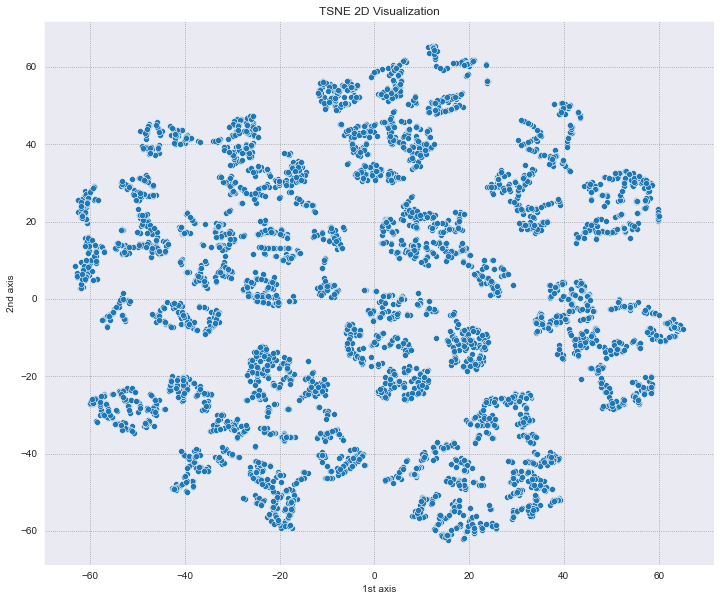

```python
plt.figure(figsize=(12, 10))
plt.title('TSNE 2D Visualization')
sns.scatterplot(x = embedings[:, 0], y = embedings[:, 1])

plt.xlabel('1st axis')
plt.ylabel('2nd axis')
plt.show()
```

На двухмерной визуализации видны не очень плотные кластеры и трудно определить их количество. Я бы сказал, что вроде видно 7 выделяющихся кластеров. Напомним, что классов в датасете всего 4.

## TSNE 3D визуализация

```python
%%time

from sklearn.manifold import TSNE

model = TSNE(n_components=3, metric='euclidean', learning_rate=200, square_distances=True, init='pca')

embedings = model.fit_transform(X)

embedings.shape
```

```
Wall time: 2min 55s
```

```
(6665, 3)
```

```python
fig = go.Figure(data=[go.Scatter3d(x=embedings[:, 0],
                                   y=embedings[:, 1],
                                   z=embedings[:, 2],
                                   mode='markers',
                                   marker=dict(
                                        size=3,
                                        opacity=0.8
                                    )
                                  )
                     ],
                layout={'height':750, 'width':750}
               )

fig.show()
```

[interactive chart not shown]

Результаты визуализации:

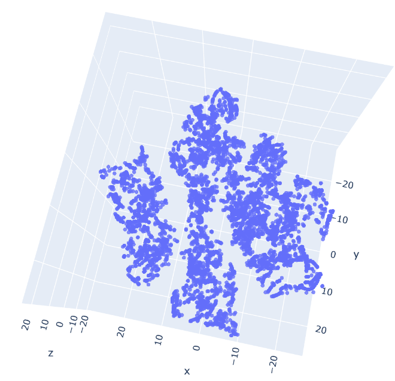

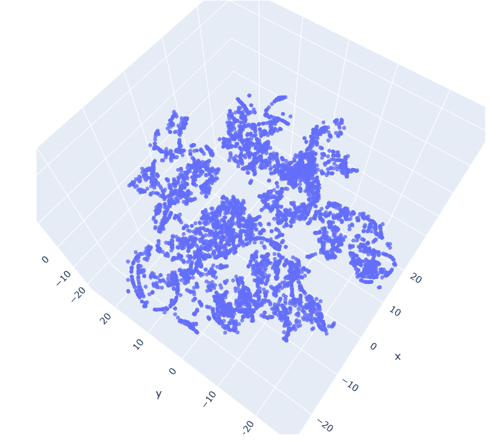

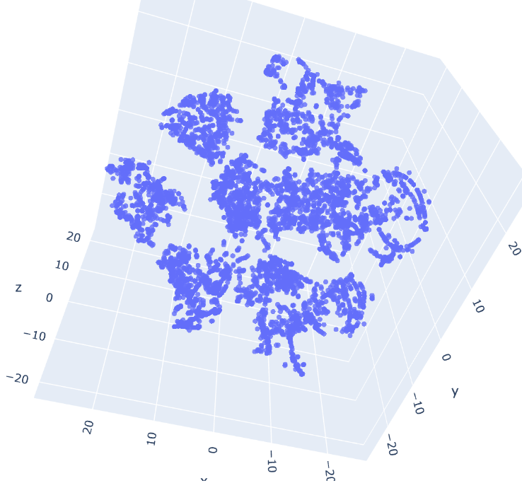

На трехмерной визуализации ещё сложнее визуально оценить кол-во класетров, но их явно не 4, мне кажется что-то около 7-8.

# Кластеризация

В данной задаче известная исходная разметка на классы и необходимо максимизировать следующие supervised метрики:

- completeness_score (насколько каждый класс соответствует одному кластеру)
- homogeneity_score (насколько каждый кластер содержит только элементы одного класса)
- v_measure_score (гармоническое среднее двух предыдущих метрик)
- adjusted_rand_score (мера сходства без учета перестановок и замены меток)

Для решения задачи были выбраны следующие алгоритмы и их паарметры:

- Kmeans Clustering, n_clusters = 2..10
- Agglomerative Clustering n_clusters = 2..10; linkage = 'ward', 'complete', 'average', 'single'
- Spectral Clustering n_clusters = 2..10; affinity='rbf'
- Birch Clustering n_clusters = 2..10

Ниже реализована функция для визуализации результатов supervised метрик в зависимости от кол-ва кластеров, чтобы не дублировать код.

```python
# функция отрисовки графиков supervised метрик
def plot_supervised_metrics(completeness_scores, homogeneity_scores, v_measure_scores, adjusted_rand_scores):
    plt.figure(figsize=(25,12))

    ax1 = plt.subplot(2, 2, 1)
    ax1.set_title('Completeness_score per n_clusters')
    sns.lineplot(x = list(completeness_scores.keys()), y = list(completeness_scores.values()), marker = 'o', ax = ax1)
    ax1.set_xlabel('n_clusters')
    ax1.set_ylabel('completeness_score')

    ax2 = plt.subplot(2, 2, 2)
    ax2.set_title('Homogeneity_score per n_clusters')
    sns.lineplot(x = list(homogeneity_scores.keys()), y = list(homogeneity_scores.values()), marker = 'o', ax = ax2)
    ax2.set_xlabel('n_clusters')
    ax2.set_ylabel('homogeneity_score')

    ax3 = plt.subplot(2, 2, 3)
    ax3.set_title('V_measure_score per n_clusters')
    sns.lineplot(x = list(v_measure_scores.keys()), y = list(v_measure_scores.values()), marker = 'o', ax = ax3)
    ax3.set_xlabel('n_clusters')
    ax3.set_ylabel('v_measure_score')

    ax4 = plt.subplot(2, 2, 4)
    ax4.set_title('Adjusted_rand_score per n_clusters')
    sns.lineplot(x = list(adjusted_rand_scores.keys()), y = list(adjusted_rand_scores.values()), marker = 'o', ax = ax4)
    ax4.set_xlabel('n_clusters')
    ax4.set_ylabel('adjusted_rand_score')

    plt.show()
```

## Kmeans Clustering

```python
from sklearn.cluster import KMeans
from sklearn.metrics import completeness_score, homogeneity_score, v_measure_score, adjusted_rand_score
from tqdm import tqdm
```

```python
completeness_scores = {}
homogeneity_scores = {}
v_measure_scores = {}
adjusted_rand_scores = {}

n_clusters_grid = np.arange(2, 11)

for n_clusters in tqdm(n_clusters_grid):
    model = KMeans(n_clusters=n_clusters, init='k-means++', random_state=42)
    labels = model.fit_predict(X)

    completeness_scores[n_clusters] = completeness_score(y, labels)
    homogeneity_scores[n_clusters] = homogeneity_score(y, labels)
    v_measure_scores[n_clusters] = v_measure_score(y, labels)
    adjusted_rand_scores[n_clusters] = adjusted_rand_score(y, labels)
```

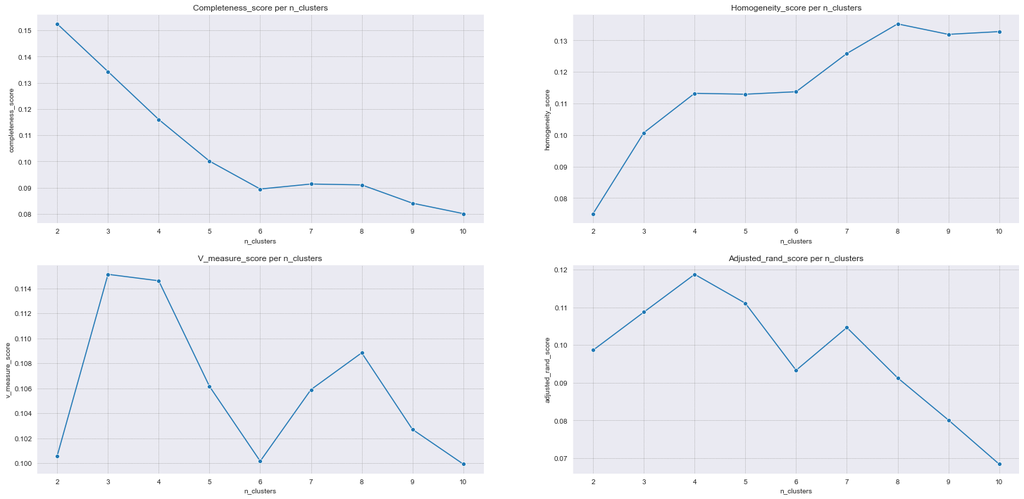

```python
plot_supervised_metrics(completeness_scores, homogeneity_scores, v_measure_scores, adjusted_rand_scores)
```

```python
best_key_completeness = max(completeness_scores, key = completeness_scores.get)
print(f'Best completeness_score = {completeness_scores[best_key_completeness]} with n_cluster = {best_key_completeness}' )
best_key_homogeneity = max(homogeneity_scores, key = homogeneity_scores.get)
print(f'Best homogeneity_score = {homogeneity_scores[best_key_homogeneity]} with n_cluster = {best_key_homogeneity}' )
best_key_v_measure = max(v_measure_scores, key = v_measure_scores.get)
print(f'Best v_measure_score = {v_measure_scores[best_key_v_measure]} with n_cluster = {best_key_v_measure}' )
best_key_adjusted_rand = max(adjusted_rand_scores, key = adjusted_rand_scores.get)
print(f'Best adjusted_rand_score = {adjusted_rand_scores[best_key_adjusted_rand]} with n_cluster = {best_key_adjusted_rand}' )
```

```
Best completeness_score = 0.15246394050712106 with n_cluster = 2
Best homogeneity_score = 0.13523126061720508 with n_cluster = 8
Best v_measure_score = 0.11511250852790564 with n_cluster = 3
Best adjusted_rand_score = 0.1187269833007104 with n_cluster = 4
```

По всем метрикам получились разные результаты по количеству кластеров. Логично будет оценивать по v_measure_score, так как это гармоническое среднее completeness_score и homogeneity_score, результаты которых сильно разнятся (2 и 8), но они очень важны и их нужно как-то учесть. Оптимальный результат по v_measure_score это 3. Также логично оценивать по adjusted_rand_score, в этом случае оптимальный результат 4 кластера, как и исходная разметка.

Таким образом, пока оставим два лучших параметра по двум материкам алгоритма Kmeans:

- Best v_measure_score = 0.11511250852790564 with n_cluster = 3
- Best adjusted_rand_score = 0.1187269833007104 with n_cluster = 4

А после перебора других алгоритмов в подведении итогов окночательно определимся, какие параметры можно считать оптимальными.

## Agglomerative Clustering

```python
from sklearn.cluster import AgglomerativeClustering
from sklearn.metrics import completeness_score, homogeneity_score, v_measure_score, adjusted_rand_score
from tqdm import tqdm
```

### Ward linkage

```python
completeness_scores = {}
homogeneity_scores = {}
v_measure_scores = {}
adjusted_rand_scores = {}

n_clusters_grid = np.arange(2, 11)

for n_clusters in tqdm(n_clusters_grid):
    model = AgglomerativeClustering(n_clusters=n_clusters, linkage='ward')
    labels = model.fit_predict(X)

    completeness_scores[n_clusters] = completeness_score(y, labels)
    homogeneity_scores[n_clusters] = homogeneity_score(y, labels)
    v_measure_scores[n_clusters] = v_measure_score(y, labels)
    adjusted_rand_scores[n_clusters] = adjusted_rand_score(y, labels)
```

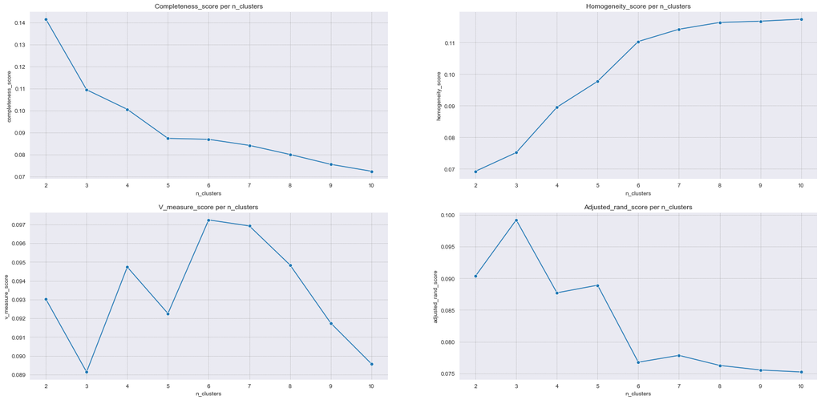

```python
plot_supervised_metrics(completeness_scores, homogeneity_scores, v_measure_scores, adjusted_rand_scores)
```

```python
best_key_completeness = max(completeness_scores, key = completeness_scores.get)
print(f'Best completeness_score = {completeness_scores[best_key_completeness]} with n_cluster = {best_key_completeness}' )
best_key_homogeneity = max(homogeneity_scores, key = homogeneity_scores.get)
print(f'Best homogeneity_score = {homogeneity_scores[best_key_homogeneity]} with n_cluster = {best_key_homogeneity}' )
best_key_v_measure = max(v_measure_scores, key = v_measure_scores.get)
print(f'Best v_measure_score = {v_measure_scores[best_key_v_measure]} with n_cluster = {best_key_v_measure}' )
best_key_adjusted_rand = max(adjusted_rand_scores, key = adjusted_rand_scores.get)
print(f'Best adjusted_rand_score = {adjusted_rand_scores[best_key_adjusted_rand]} with n_cluster = {best_key_adjusted_rand}' )
```

```
Best completeness_score = 0.1415635694707251 with n_cluster = 2
Best homogeneity_score = 0.1174019587449758 with n_cluster = 10
Best v_measure_score = 0.09724049332635548 with n_cluster = 6
Best adjusted_rand_score = 0.09921053722702518 with n_cluster = 3
```

Картина такая же, результаты completeness_score и homogeneity_score сильно разнятся. Учитывая v_measure_score и adjusted_rand_score получаем оптимальное кол-ва кластеров 6 и 3 соответственно, но результаты метрик хуже, чем полученные при Kmeans, так что AgglomerativeClustering с способом связи ward проигрывает Kmeans.

### Complete linkage

```python
completeness_scores = {}
homogeneity_scores = {}
v_measure_scores = {}
adjusted_rand_scores = {}

n_clusters_grid = np.arange(2, 11)

for n_clusters in tqdm(n_clusters_grid):
    model = AgglomerativeClustering(n_clusters=n_clusters, linkage='complete')
    labels = model.fit_predict(X)

    completeness_scores[n_clusters] = completeness_score(y, labels)
    homogeneity_scores[n_clusters] = homogeneity_score(y, labels)
    v_measure_scores[n_clusters] = v_measure_score(y, labels)
    adjusted_rand_scores[n_clusters] = adjusted_rand_score(y, labels)
```

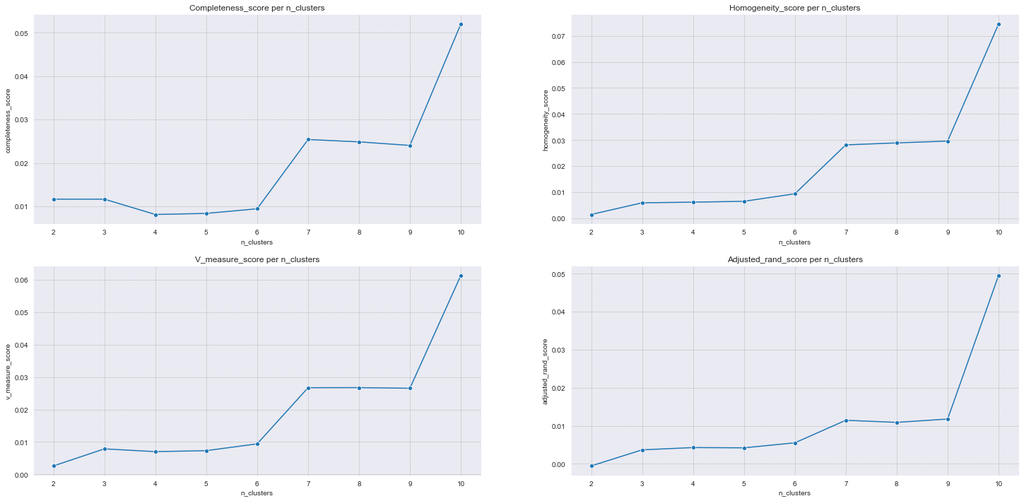

```python
plot_supervised_metrics(completeness_scores, homogeneity_scores, v_measure_scores, adjusted_rand_scores)
```

```python
best_key_completeness = max(completeness_scores, key = completeness_scores.get)
print(f'Best completeness_score = {completeness_scores[best_key_completeness]} with n_cluster = {best_key_completeness}' )
best_key_homogeneity = max(homogeneity_scores, key = homogeneity_scores.get)
print(f'Best homogeneity_score = {homogeneity_scores[best_key_homogeneity]} with n_cluster = {best_key_homogeneity}' )
best_key_v_measure = max(v_measure_scores, key = v_measure_scores.get)
print(f'Best v_measure_score = {v_measure_scores[best_key_v_measure]} with n_cluster = {best_key_v_measure}' )
best_key_adjusted_rand = max(adjusted_rand_scores, key = adjusted_rand_scores.get)
print(f'Best adjusted_rand_score = {adjusted_rand_scores[best_key_adjusted_rand]} with n_cluster = {best_key_adjusted_rand}' )
```

```
Best completeness_score = 0.05203940458940946 with n_cluster = 10
Best homogeneity_score = 0.07451648942111609 with n_cluster = 10
Best v_measure_score = 0.06128191455461406 with n_cluster = 10
Best adjusted_rand_score = 0.049539696125494796 with n_cluster = 10
```

С способом связи complete получилось оптимальное кол-во кластеров 10 для всех метрик, но при этом результаты значительно проигрывают предыдущим и это очень далеко от исходной разметки.

### Average linkage

```python
completeness_scores = {}
homogeneity_scores = {}
v_measure_scores = {}
adjusted_rand_scores = {}

n_clusters_grid = np.arange(2, 11)

for n_clusters in tqdm(n_clusters_grid):
    model = AgglomerativeClustering(n_clusters=n_clusters, linkage='average')
    labels = model.fit_predict(X)

    completeness_scores[n_clusters] = completeness_score(y, labels)
    homogeneity_scores[n_clusters] = homogeneity_score(y, labels)
    v_measure_scores[n_clusters] = v_measure_score(y, labels)
    adjusted_rand_scores[n_clusters] = adjusted_rand_score(y, labels)
```

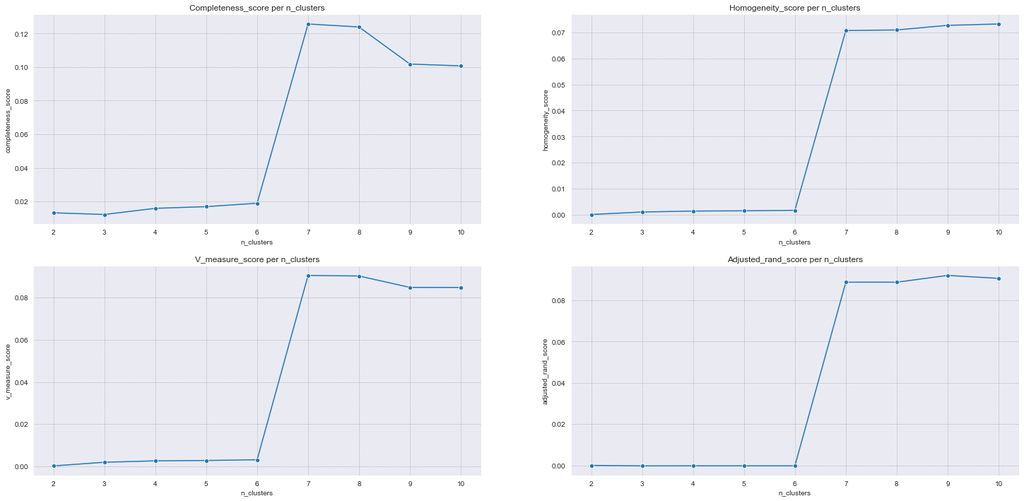

```python
plot_supervised_metrics(completeness_scores, homogeneity_scores, v_measure_scores, adjusted_rand_scores)
```

```python
best_key_completeness = max(completeness_scores, key = completeness_scores.get)
print(f'Best completeness_score = {completeness_scores[best_key_completeness]} with n_cluster = {best_key_completeness}' )
best_key_homogeneity = max(homogeneity_scores, key = homogeneity_scores.get)
print(f'Best homogeneity_score = {homogeneity_scores[best_key_homogeneity]} with n_cluster = {best_key_homogeneity}' )
best_key_v_measure = max(v_measure_scores, key = v_measure_scores.get)
print(f'Best v_measure_score = {v_measure_scores[best_key_v_measure]} with n_cluster = {best_key_v_measure}' )
best_key_adjusted_rand = max(adjusted_rand_scores, key = adjusted_rand_scores.get)
print(f'Best adjusted_rand_score = {adjusted_rand_scores[best_key_adjusted_rand]} with n_cluster = {best_key_adjusted_rand}' )
```

```
Best completeness_score = 0.1256660814617564 with n_cluster = 7
Best homogeneity_score = 0.07325834462502673 with n_cluster = 10
Best v_measure_score = 0.09052386145706547 with n_cluster = 7
Best adjusted_rand_score = 0.09203720046013267 with n_cluster = 9
```

Если использовать связь average, то снова результаты сильно проигрывают и сильно отличаются от исходной разметки на 4 класса.

### Single linkage

```python
completeness_scores = {}
homogeneity_scores = {}
v_measure_scores = {}
adjusted_rand_scores = {}

n_clusters_grid = np.arange(2, 11)

for n_clusters in tqdm(n_clusters_grid):
    model = AgglomerativeClustering(n_clusters=n_clusters, linkage='single')
    labels = model.fit_predict(X)

    completeness_scores[n_clusters] = completeness_score(y, labels)
    homogeneity_scores[n_clusters] = homogeneity_score(y, labels)
    v_measure_scores[n_clusters] = v_measure_score(y, labels)
    adjusted_rand_scores[n_clusters] = adjusted_rand_score(y, labels)
```

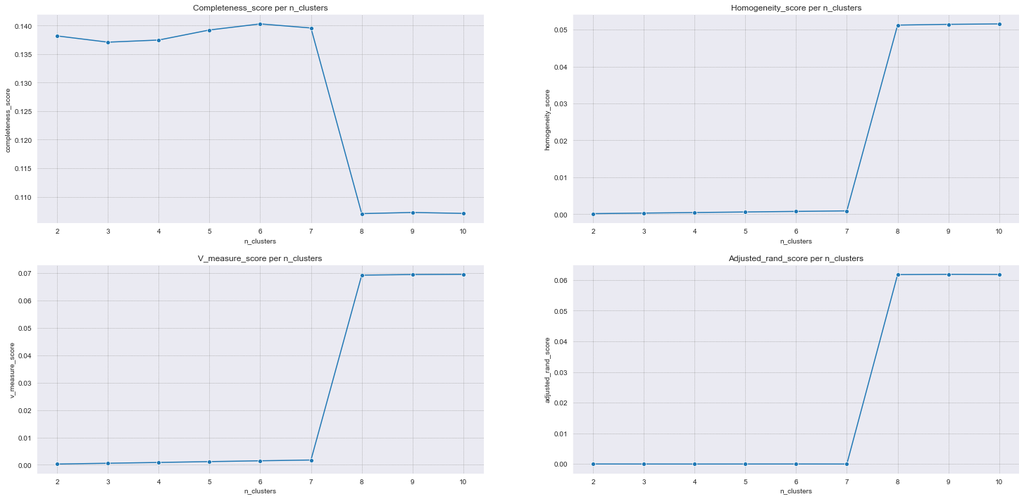

```python
plot_supervised_metrics(completeness_scores, homogeneity_scores, v_measure_scores, adjusted_rand_scores)
```

```python
best_key_completeness = max(completeness_scores, key = completeness_scores.get)
print(f'Best completeness_score = {completeness_scores[best_key_completeness]} with n_cluster = {best_key_completeness}' )
best_key_homogeneity = max(homogeneity_scores, key = homogeneity_scores.get)
print(f'Best homogeneity_score = {homogeneity_scores[best_key_homogeneity]} with n_cluster = {best_key_homogeneity}' )
best_key_v_measure = max(v_measure_scores, key = v_measure_scores.get)
print(f'Best v_measure_score = {v_measure_scores[best_key_v_measure]} with n_cluster = {best_key_v_measure}' )
best_key_adjusted_rand = max(adjusted_rand_scores, key = adjusted_rand_scores.get)
print(f'Best adjusted_rand_score = {adjusted_rand_scores[best_key_adjusted_rand]} with n_cluster = {best_key_adjusted_rand}' )
```

```
Best completeness_score = 0.14028600849212242 with n_cluster = 6
Best homogeneity_score = 0.05155886634582873 with n_cluster = 10
Best v_measure_score = 0.06960378282708769 with n_cluster = 10
Best adjusted_rand_score = 0.061843661819731326 with n_cluster = 9
```

При использовании способа связи single получена метрика completeness_score приблизительно как у kmeans, но при этом все остальные метрики очень плохи, так что этот алгоритм тоже не рассматриваем.

Подведем итог по иерархической кластеризации. При использовании любого способа связи алгоритм отрабатывает хуже по supervised метрикам, чем Kmeans, так что лучшим по прежнему остаются результаты Kmeans, далее рассмотрим другие алгоритмы.

## Spectral Clustering

При использовании affinity='nearest_neighbors' получался не полносвязный граф, во избежании ошибок кластеризации, было решено использовать только affinity = 'rbf'.

```python
from sklearn.cluster import SpectralClustering
from sklearn.metrics import completeness_score, homogeneity_score, v_measure_score, adjusted_rand_score
from tqdm import tqdm
```

```python
completeness_scores = {}
homogeneity_scores = {}
v_measure_scores = {}
adjusted_rand_scores = {}

n_clusters_grid = np.arange(2, 11)

for n_clusters in tqdm(n_clusters_grid):
    model = SpectralClustering(n_clusters=n_clusters, affinity='rbf', n_jobs=-1)
    labels = model.fit_predict(X)

    completeness_scores[n_clusters] = completeness_score(y, labels)
    homogeneity_scores[n_clusters] = homogeneity_score(y, labels)
    v_measure_scores[n_clusters] = v_measure_score(y, labels)
    adjusted_rand_scores[n_clusters] = adjusted_rand_score(y, labels)
```

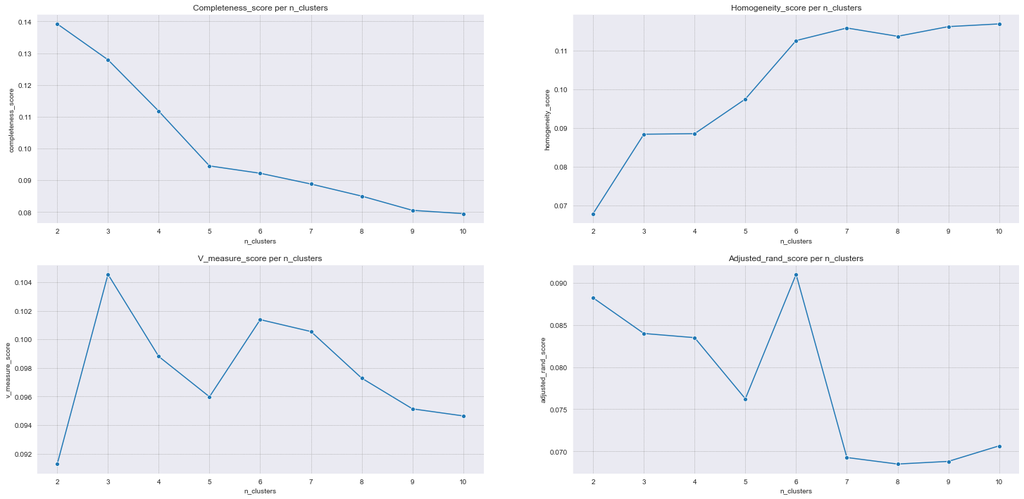

```python
plot_supervised_metrics(completeness_scores, homogeneity_scores, v_measure_scores, adjusted_rand_scores)
```

```python
best_key_completeness = max(completeness_scores, key = completeness_scores.get)
print(f'Best completeness_score = {completeness_scores[best_key_completeness]} with n_cluster = {best_key_completeness}' )
best_key_homogeneity = max(homogeneity_scores, key = homogeneity_scores.get)
print(f'Best homogeneity_score = {homogeneity_scores[best_key_homogeneity]} with n_cluster = {best_key_homogeneity}' )
best_key_v_measure = max(v_measure_scores, key = v_measure_scores.get)
print(f'Best v_measure_score = {v_measure_scores[best_key_v_measure]} with n_cluster = {best_key_v_measure}' )
best_key_adjusted_rand = max(adjusted_rand_scores, key = adjusted_rand_scores.get)
print(f'Best adjusted_rand_score = {adjusted_rand_scores[best_key_adjusted_rand]} with n_cluster = {best_key_adjusted_rand}' )
```

```
Best completeness_score = 0.13920586437728547 with n_cluster = 2
Best homogeneity_score = 0.11686566239892196 with n_cluster = 10
Best v_measure_score = 0.10454836968710311 with n_cluster = 3
Best adjusted_rand_score = 0.09104192166453881 with n_cluster = 6
```

При спектральной кластеризации с использованием rbf результат по метрике completeness_score чуть хуже. чем у kmeans, разброс в значениях между homogeneity_score снова большой. Метрика v_measure_score тоже немного проигрыват, хотя оптимальное кол-во кластеров совпадает. Метрика adjusted_rand_score также проигрывает, так что по прежнему лучший Kmeans.

## Birch Clustering

```python
from sklearn.cluster import Birch
from sklearn.metrics import completeness_score, homogeneity_score, v_measure_score, adjusted_rand_score
from tqdm import tqdm
```

```python
completeness_scores = {}
homogeneity_scores = {}
v_measure_scores = {}
adjusted_rand_scores = {}

n_clusters_grid = np.arange(2, 11)

for n_clusters in tqdm(n_clusters_grid):
    model = Birch(n_clusters=n_clusters)
    labels = model.fit_predict(X)

    completeness_scores[n_clusters] = completeness_score(y, labels)
    homogeneity_scores[n_clusters] = homogeneity_score(y, labels)
    v_measure_scores[n_clusters] = v_measure_score(y, labels)
    adjusted_rand_scores[n_clusters] = adjusted_rand_score(y, labels)
```

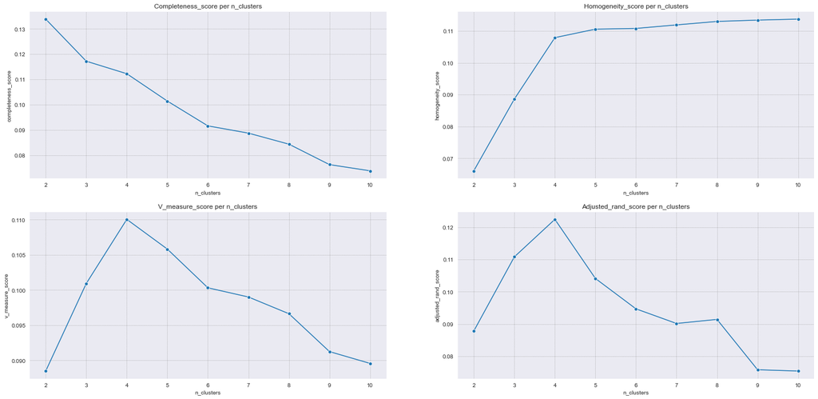

```python
plot_supervised_metrics(completeness_scores, homogeneity_scores, v_measure_scores, adjusted_rand_scores)
```

```python
best_key_completeness = max(completeness_scores, key = completeness_scores.get)
print(f'Best completeness_score = {completeness_scores[best_key_completeness]} with n_cluster = {best_key_completeness}' )
best_key_homogeneity = max(homogeneity_scores, key = homogeneity_scores.get)
print(f'Best homogeneity_score = {homogeneity_scores[best_key_homogeneity]} with n_cluster = {best_key_homogeneity}' )
best_key_v_measure = max(v_measure_scores, key = v_measure_scores.get)
print(f'Best v_measure_score = {v_measure_scores[best_key_v_measure]} with n_cluster = {best_key_v_measure}' )
best_key_adjusted_rand = max(adjusted_rand_scores, key = adjusted_rand_scores.get)
print(f'Best adjusted_rand_score = {adjusted_rand_scores[best_key_adjusted_rand]} with n_cluster = {best_key_adjusted_rand}' )
```

```
Best completeness_score = 0.13385227251249704 with n_cluster = 2
Best homogeneity_score = 0.11371575440523786 with n_cluster = 10
Best v_measure_score = 0.11004050776185542 with n_cluster = 4
Best adjusted_rand_score = 0.12250228750313585 with n_cluster = 4
```

При кластеризации алгоритмом Birch получена метрика v_measure_score = 0.11004050776185542, что немного хуже Kmeans (у Kmeans было 0.11511250852790564), при этом оптимальное кол-во кластеров 4 совпадает и истинной разметкой. Кроме того, метрика adjusted_rand_score = 0.12250228750313585 лучше, чем при кластеризации Kmeans (у Kmeans было 0.1187269833007104), и оптимальное кол-во кластеров вновь совпадает с истинной разметкой - 4. Запомним эти результаты и подведем итоги проделанной работы.

Лучшие параметры Birch:

- Best v_measure_score = 0.11004050776185542 with n_cluster = 4
- Best adjusted_rand_score = 0.12250228750313585 with n_cluster = 4

# Выводы

Перебирая алгоритмы кластеризации с настраиваемым числом кластеров я уже думал, что ни один алгоритм на данном датасете не сработает лучше Kmeans, пока не дошёл до Birch. Алгоритм Birch хуже по v_measure_score, но лучше по adjusted_rand_score примерно на одинаковую величину. По другим метрикам немного проигрывает, но их было решено учитывать только в совокупности (v_measure_score). Я выберу лучшим алгоритм Birch(n_clusters), так как у него есть ещё настраиваемые гиперпараметры, которые можно перебрать и возможно получить ещё лучше результат, а вот Kmeans изобилием гиперпараметров не обладает.

В целом, похоже я подобрал не лучший датасет для кластеризации, так как даже на визуализациях с помощью TSNE видно, что кластеры есть, но они не плотные и очень трудно их хорошо разделить. Отметим, что возможно разметка датасета не очень хороша и несколько разных кластеров попадают по разметке в один класс. Так же возможно стоит попробовать другие метрики расстояния, для тех алгоритмов, где это можно сделать, но пока ограничимся евклидовым расстоянием.